# Final Product: Billboard Top 5 Hits Through The Years: Are Songs Getting Simpler?

**Name:** Wilson Fredbeck

**Date:** 12/10/2025

## Final Infographic

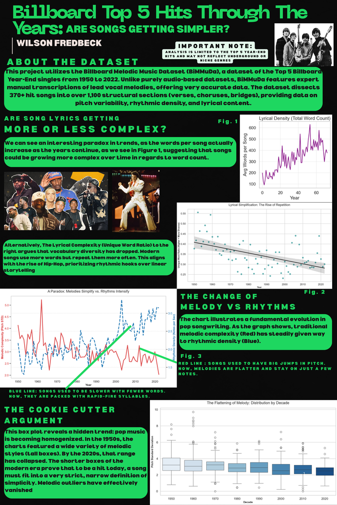

```python
from IPython.display import Image, display

display(Image(filename='final-infographic.png'))
```

### Description of the Final Product

**Billboard Top 5 Hits Through The Years: Are Songs Getting Simpler?** is a data visualization infographic that investigates the evolution of musical complexity in the Billboard Year-End Top 5 from 1950 to 2022.

**The Core Narrative:** Common wisdom suggests that pop music is "getting dumber." This project uses the BiMMuDa dataset to test that hypothesis. The analysis reveals a complex trade-off: while **Melodic Complexity** (Pitch STD) has declined by nearly 40%, **Rhythmic Density** (Notes per second) has doubled. This creates the paradox that music hasn't just simplified; it has shifted its focus from melody to rhythm, largely driven by the rise of Hip-Hop in the 1990s. Additionally, there are now more words in songs, but the **Unique Word Ratio** shows that while this may be true, songs have become more repetitive and less complex.

**Key Visualizations:**

1. **Lyrical Simplification (Scatter Plot):** Demonstrates the statistical decline in unique vocabulary usage.
2. **The Great Trade-Off (Dual-Axis Chart):** Visualizes the historical intersection where rhythm overtook melody (c. 1990).
3. **The Homogenization (Box Plot):** Illustrates how the "range" of acceptable melodic complexity has shrunk over time.

### Project Manifest

| Resource Name | Type | Description | Link/Source |
| --- | --- | --- | --- |
| **bimmuda_per_song_full.csv** | Data File | The primary dataset containing metadata (Artist, Title, Year) and lyrical stats for Top 5 hits. | [BiMMuDa Dataset](https://doi.org/10.5334/tismir.168.s1) |
| **bimmuda_per_melody_full.csv** | Data File | The granular dataset containing melodic features (Pitch STD, Onset Density) for individual song sections. | [BiMMuDa Dataset](https://doi.org/10.5334/tismir.168.s1) |
| **N1-data-info.ipynb** | Jupyter Notebook | **Data Preparation:** Handles data loading, merging, and cleaning of the two CSV files. | Local File |
| **N2-data-exploration.ipynb** | Jupyter Notebook | **Exploratory Analysis:** Contains initial histograms, hypothesis testing, and generation of all analysis plots. | Local File |
| **N3-final-product.ipynb** | Jupyter Notebook | **Final Product:** The presentation layer displaying the final infographic and project summary. | Local File |
| **final-infographic.png** | Image File | The final infographic in PNG format. | Local File |
| **Storyboard Photos** | Image Files | Photos of the paper prototyping/storyboarding process. | Local Folder |
| **Canva** | Design Tool | Used to assemble the Python-generated plots into the final poster layout. | [Canva.com](https://www.canva.com) |
| **Hamilton et al. (2024)** | Academic Paper | "BiMMuDa: The Billboard Melodic Music Dataset" (Source of the data methodology). | [Paper Link](https://transactions.ismir.net/articles/168/files/66b30cacae2f2.pdf) |